# Load the data

```python
df = pd.read_csv(os.getcwd()+"/data/day.csv")
df["dteday"] = pd.to_datetime(df["dteday"])
df = df.sort_values(by="dteday",ascending=True)
df.head()
```

|  | instant | dteday | season | yr | mnth | holiday | weekday | workingday | weathersit | temp | atemp | hum | windspeed | casual | registered | cnt |
| --- | --- | --- | --- | --- | --- | --- | --- | --- | --- | --- | --- | --- | --- | --- | --- | --- |
| 0 | 1 | 2011-01-01 | 1 | 0 | 1 | 0 | 6 | 0 | 2 | 0.344167 | 0.363625 | 0.805833 | 0.160446 | 331 | 654 | 985 |
| 1 | 2 | 2011-01-02 | 1 | 0 | 1 | 0 | 0 | 0 | 2 | 0.363478 | 0.353739 | 0.696087 | 0.248539 | 131 | 670 | 801 |
| 2 | 3 | 2011-01-03 | 1 | 0 | 1 | 0 | 1 | 1 | 1 | 0.196364 | 0.189405 | 0.437273 | 0.248309 | 120 | 1229 | 1349 |
| 3 | 4 | 2011-01-04 | 1 | 0 | 1 | 0 | 2 | 1 | 1 | 0.200000 | 0.212122 | 0.590435 | 0.160296 | 108 | 1454 | 1562 |
| 4 | 5 | 2011-01-05 | 1 | 0 | 1 | 0 | 3 | 1 | 1 | 0.226957 | 0.229270 | 0.436957 | 0.186900 | 82 | 1518 | 1600 |

# Explorative data analysis

## Profile Report

*Reminder: show correlation matrix*

Overview

Dataset info

| Number of variables | 16 |
| --- | --- |
| Number of observations | 731 |
| Total Missing (%) | 0.0% |
| Total size in memory | 97.1 KiB |
| Average record size in memory | 136.0 B |

Variables types

| Numeric | 10 |
| --- | --- |
| Categorical | 0 |
| Boolean | 3 |
| Date | 1 |
| Text (Unique) | 0 |
| Rejected | 2 |
| Unsupported | 0 |

Warnings

- `atemp` is highly correlated with `temp` (ρ = 0.9917) Rejected

- `cnt` is highly correlated with `registered` (ρ = 0.94552) Rejected

- `weekday` has 105 / 14.4% zeros Zeros

Variables

atemp  
Highly correlated

*This variable is highly correlated with `temp` and should be ignored for analysis*

| Correlation | 0.9917 |
| --- | --- |

casual  
Numeric

| Distinct count | 606 |
| --- | --- |
| Unique (%) | 82.9% |
| Missing (%) | 0.0% |
| Missing (n) | 0 |
| Infinite (%) | 0.0% |
| Infinite (n) | 0 |

| Mean | 848.18 |
| --- | --- |
| Minimum | 2 |
| Maximum | 3410 |
| Zeros (%) | 0.0% |

Toggle details

**Statistics**

Quantile statistics

| Minimum | 2 |
| --- | --- |
| 5-th percentile | 88 |
| Q1 | 315.5 |
| Median | 713 |
| Q3 | 1096 |
| 95-th percentile | 2355 |
| Maximum | 3410 |
| Range | 3408 |
| Interquartile range | 780.5 |

Descriptive statistics

| Standard deviation | 686.62 |
| --- | --- |
| Coef of variation | 0.80953 |
| Kurtosis | 1.3221 |
| Mean | 848.18 |
| MAD | 520.81 |
| Skewness | 1.2665 |
| Sum | 620017 |
| Variance | 471450 |
| Memory size | 11.4 KiB |

**Histogram**

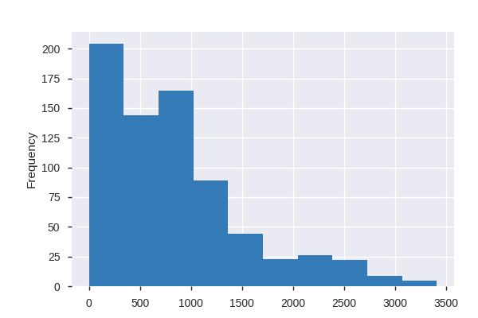

**Common Values**

| Value | Count | Frequency (%) |  |
| --- | --- | --- | --- |
| 968 | 4 | 0.5% |  |
| 120 | 4 | 0.5% |  |
| 244 | 3 | 0.4% |  |
| 653 | 3 | 0.4% |  |
| 639 | 3 | 0.4% |  |
| 123 | 3 | 0.4% |  |
| 140 | 3 | 0.4% |  |
| 163 | 3 | 0.4% |  |
| 775 | 3 | 0.4% |  |
| 692 | 2 | 0.3% |  |
| Other values (596) | 700 | 95.8% |  |

**Extreme Values**

Minimum 5 values

| Value | Count | Frequency (%) |  |
| --- | --- | --- | --- |
| 2 | 1 | 0.1% |  |
| 9 | 2 | 0.3% |  |
| 15 | 1 | 0.1% |  |
| 25 | 1 | 0.1% |  |
| 34 | 1 | 0.1% |  |

Maximum 5 values

| Value | Count | Frequency (%) |  |
| --- | --- | --- | --- |
| 3155 | 1 | 0.1% |  |
| 3160 | 1 | 0.1% |  |
| 3252 | 1 | 0.1% |  |
| 3283 | 1 | 0.1% |  |
| 3410 | 1 | 0.1% |  |

cnt  
Highly correlated

*This variable is highly correlated with `registered` and should be ignored for analysis*

| Correlation | 0.94552 |
| --- | --- |

dteday  
Date

| Distinct count | 731 |
| --- | --- |
| Unique (%) | 100.0% |
| Missing (%) | 0.0% |
| Missing (n) | 0 |
| Infinite (%) | 0.0% |
| Infinite (n) | 0 |

| Minimum | 2011-01-01 00:00:00 |
| --- | --- |
| Maximum | 2012-12-31 00:00:00 |

Toggle details

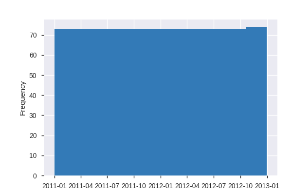

holiday  
Boolean

| Distinct count | 2 |
| --- | --- |
| Unique (%) | 0.3% |
| Missing (%) | 0.0% |
| Missing (n) | 0 |

| Mean | 0.028728 |
| --- | --- |

| 0 | 710 |
| --- | --- |
| 1 | 21 |

Toggle details

| Value | Count | Frequency (%) |  |
| --- | --- | --- | --- |
| 0 | 710 | 97.1% |  |
| 1 | 21 | 2.9% |  |

hum  
Numeric

| Distinct count | 595 |
| --- | --- |
| Unique (%) | 81.4% |
| Missing (%) | 0.0% |
| Missing (n) | 0 |
| Infinite (%) | 0.0% |
| Infinite (n) | 0 |

| Mean | 0.62789 |
| --- | --- |
| Minimum | 0 |
| Maximum | 0.9725 |
| Zeros (%) | 0.1% |

Toggle details

**Statistics**

Quantile statistics

| Minimum | 0 |
| --- | --- |
| 5-th percentile | 0.40745 |
| Q1 | 0.52 |
| Median | 0.62667 |
| Q3 | 0.73021 |
| 95-th percentile | 0.86854 |
| Maximum | 0.9725 |
| Range | 0.9725 |
| Interquartile range | 0.21021 |

Descriptive statistics

| Standard deviation | 0.14243 |
| --- | --- |
| Coef of variation | 0.22684 |
| Kurtosis | -0.06453 |
| Mean | 0.62789 |
| MAD | 0.11644 |
| Skewness | -0.069783 |
| Sum | 458.99 |
| Variance | 0.020286 |
| Memory size | 11.4 KiB |

**Histogram**

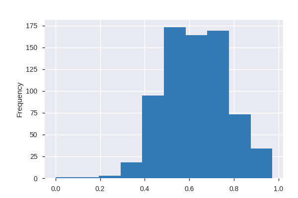

**Common Values**

| Value | Count | Frequency (%) |  |
| --- | --- | --- | --- |
| 0.613333 | 4 | 0.5% |  |
| 0.568333 | 3 | 0.4% |  |
| 0.5425 | 3 | 0.4% |  |
| 0.7529170000000001 | 3 | 0.4% |  |
| 0.697083 | 3 | 0.4% |  |
| 0.630833 | 3 | 0.4% |  |
| 0.605 | 3 | 0.4% |  |
| 0.59 | 3 | 0.4% |  |
| 0.69 | 3 | 0.4% |  |
| 0.729583 | 3 | 0.4% |  |
| Other values (585) | 700 | 95.8% |  |

**Extreme Values**

Minimum 5 values

| Value | Count | Frequency (%) |  |
| --- | --- | --- | --- |
| 0.0 | 1 | 0.1% |  |
| 0.187917 | 1 | 0.1% |  |
| 0.25416700000000003 | 1 | 0.1% |  |
| 0.275833 | 1 | 0.1% |  |
| 0.29 | 1 | 0.1% |  |

Maximum 5 values

| Value | Count | Frequency (%) |  |
| --- | --- | --- | --- |
| 0.948261 | 1 | 0.1% |  |
| 0.949583 | 1 | 0.1% |  |
| 0.9625 | 1 | 0.1% |  |
| 0.970417 | 1 | 0.1% |  |
| 0.9725 | 1 | 0.1% |  |

instant  
Numeric

| Distinct count | 731 |
| --- | --- |
| Unique (%) | 100.0% |
| Missing (%) | 0.0% |
| Missing (n) | 0 |
| Infinite (%) | 0.0% |
| Infinite (n) | 0 |

| Mean | 366 |
| --- | --- |
| Minimum | 1 |
| Maximum | 731 |
| Zeros (%) | 0.0% |

Toggle details

**Statistics**

Quantile statistics

| Minimum | 1 |
| --- | --- |
| 5-th percentile | 37.5 |
| Q1 | 183.5 |
| Median | 366 |
| Q3 | 548.5 |
| 95-th percentile | 694.5 |
| Maximum | 731 |
| Range | 730 |
| Interquartile range | 365 |

Descriptive statistics

| Standard deviation | 211.17 |
| --- | --- |
| Coef of variation | 0.57696 |
| Kurtosis | -1.2 |
| Mean | 366 |
| MAD | 182.75 |
| Skewness | 0 |
| Sum | 267546 |
| Variance | 44591 |
| Memory size | 31.4 KiB |

**Histogram**

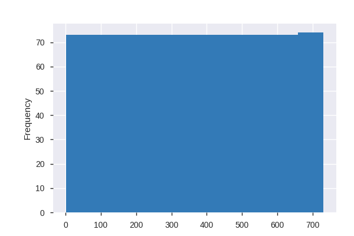

**Common Values**

| Value | Count | Frequency (%) |  |
| --- | --- | --- | --- |
| 731 | 1 | 0.1% |  |
| 251 | 1 | 0.1% |  |
| 249 | 1 | 0.1% |  |
| 248 | 1 | 0.1% |  |
| 247 | 1 | 0.1% |  |
| 246 | 1 | 0.1% |  |
| 245 | 1 | 0.1% |  |
| 244 | 1 | 0.1% |  |
| 243 | 1 | 0.1% |  |
| 242 | 1 | 0.1% |  |
| Other values (721) | 721 | 98.6% |  |

**Extreme Values**

Minimum 5 values

| Value | Count | Frequency (%) |  |
| --- | --- | --- | --- |
| 1 | 1 | 0.1% |  |
| 2 | 1 | 0.1% |  |
| 3 | 1 | 0.1% |  |
| 4 | 1 | 0.1% |  |
| 5 | 1 | 0.1% |  |

Maximum 5 values

| Value | Count | Frequency (%) |  |
| --- | --- | --- | --- |
| 727 | 1 | 0.1% |  |
| 728 | 1 | 0.1% |  |
| 729 | 1 | 0.1% |  |
| 730 | 1 | 0.1% |  |
| 731 | 1 | 0.1% |  |

mnth  
Numeric

| Distinct count | 12 |
| --- | --- |
| Unique (%) | 1.6% |
| Missing (%) | 0.0% |
| Missing (n) | 0 |
| Infinite (%) | 0.0% |
| Infinite (n) | 0 |

| Mean | 6.5198 |
| --- | --- |
| Minimum | 1 |
| Maximum | 12 |
| Zeros (%) | 0.0% |

Toggle details

**Statistics**

Quantile statistics

| Minimum | 1 |
| --- | --- |
| 5-th percentile | 1 |
| Q1 | 4 |
| Median | 7 |
| Q3 | 10 |
| 95-th percentile | 12 |
| Maximum | 12 |
| Range | 11 |
| Interquartile range | 6 |

Descriptive statistics

| Standard deviation | 3.4519 |
| --- | --- |
| Coef of variation | 0.52945 |
| Kurtosis | -1.2091 |
| Mean | 6.5198 |
| MAD | 2.9951 |
| Skewness | -0.0081487 |
| Sum | 4766 |
| Variance | 11.916 |
| Memory size | 11.4 KiB |

**Histogram**

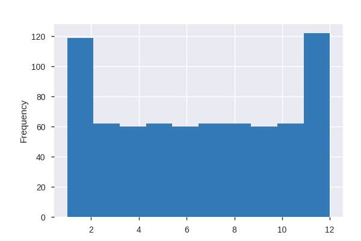

**Common Values**

| Value | Count | Frequency (%) |  |
| --- | --- | --- | --- |
| 12 | 62 | 8.5% |  |
| 10 | 62 | 8.5% |  |
| 8 | 62 | 8.5% |  |
| 7 | 62 | 8.5% |  |
| 5 | 62 | 8.5% |  |
| 3 | 62 | 8.5% |  |
| 1 | 62 | 8.5% |  |
| 11 | 60 | 8.2% |  |
| 9 | 60 | 8.2% |  |
| 6 | 60 | 8.2% |  |
| Other values (2) | 117 | 16.0% |  |

**Extreme Values**

Minimum 5 values

| Value | Count | Frequency (%) |  |
| --- | --- | --- | --- |
| 1 | 62 | 8.5% |  |
| 2 | 57 | 7.8% |  |
| 3 | 62 | 8.5% |  |
| 4 | 60 | 8.2% |  |
| 5 | 62 | 8.5% |  |

Maximum 5 values

| Value | Count | Frequency (%) |  |
| --- | --- | --- | --- |
| 8 | 62 | 8.5% |  |
| 9 | 60 | 8.2% |  |
| 10 | 62 | 8.5% |  |
| 11 | 60 | 8.2% |  |
| 12 | 62 | 8.5% |  |

registered  
Numeric

| Distinct count | 679 |
| --- | --- |
| Unique (%) | 92.9% |
| Missing (%) | 0.0% |
| Missing (n) | 0 |
| Infinite (%) | 0.0% |
| Infinite (n) | 0 |

| Mean | 3656.2 |
| --- | --- |
| Minimum | 20 |
| Maximum | 6946 |
| Zeros (%) | 0.0% |

Toggle details

**Statistics**

Quantile statistics

| Minimum | 20 |
| --- | --- |
| 5-th percentile | 1177.5 |
| Q1 | 2497 |
| Median | 3662 |
| Q3 | 4776.5 |
| 95-th percentile | 6280.5 |
| Maximum | 6946 |
| Range | 6926 |
| Interquartile range | 2279.5 |

Descriptive statistics

| Standard deviation | 1560.3 |
| --- | --- |
| Coef of variation | 0.42675 |
| Kurtosis | -0.7131 |
| Mean | 3656.2 |
| MAD | 1263.7 |
| Skewness | 0.043659 |
| Sum | 2672662 |
| Variance | 2434400 |
| Memory size | 11.4 KiB |

**Histogram**

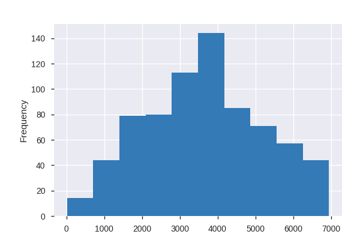

**Common Values**

| Value | Count | Frequency (%) |  |
| --- | --- | --- | --- |
| 4841 | 3 | 0.4% |  |
| 1707 | 3 | 0.4% |  |
| 6248 | 3 | 0.4% |  |
| 3578 | 2 | 0.3% |  |
| 4429 | 2 | 0.3% |  |
| 1730 | 2 | 0.3% |  |
| 3848 | 2 | 0.3% |  |
| 2115 | 2 | 0.3% |  |
| 3840 | 2 | 0.3% |  |
| 674 | 2 | 0.3% |  |
| Other values (669) | 708 | 96.9% |  |

**Extreme Values**

Minimum 5 values

| Value | Count | Frequency (%) |  |
| --- | --- | --- | --- |
| 20 | 1 | 0.1% |  |
| 416 | 1 | 0.1% |  |
| 432 | 1 | 0.1% |  |
| 451 | 1 | 0.1% |  |
| 472 | 1 | 0.1% |  |

Maximum 5 values

| Value | Count | Frequency (%) |  |
| --- | --- | --- | --- |
| 6844 | 1 | 0.1% |  |
| 6898 | 1 | 0.1% |  |
| 6911 | 1 | 0.1% |  |
| 6917 | 1 | 0.1% |  |
| 6946 | 1 | 0.1% |  |

season  
Numeric

| Distinct count | 4 |
| --- | --- |
| Unique (%) | 0.5% |
| Missing (%) | 0.0% |
| Missing (n) | 0 |
| Infinite (%) | 0.0% |
| Infinite (n) | 0 |

| Mean | 2.4966 |
| --- | --- |
| Minimum | 1 |
| Maximum | 4 |
| Zeros (%) | 0.0% |

Toggle details

**Statistics**

Quantile statistics

| Minimum | 1 |
| --- | --- |
| 5-th percentile | 1 |
| Q1 | 2 |
| Median | 3 |
| Q3 | 3 |
| 95-th percentile | 4 |
| Maximum | 4 |
| Range | 3 |
| Interquartile range | 1 |

Descriptive statistics

| Standard deviation | 1.1108 |
| --- | --- |
| Coef of variation | 0.44493 |
| Kurtosis | -1.3426 |
| Mean | 2.4966 |
| MAD | 0.99111 |
| Skewness | -0.00038428 |
| Sum | 1825 |
| Variance | 1.2339 |
| Memory size | 11.4 KiB |

**Histogram**

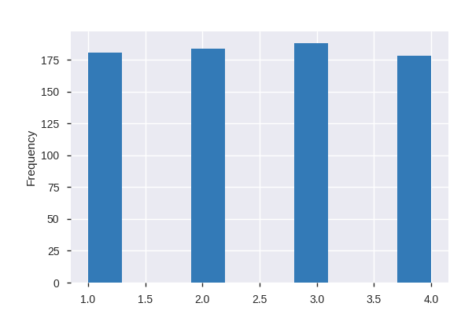

**Common Values**

| Value | Count | Frequency (%) |  |
| --- | --- | --- | --- |
| 3 | 188 | 25.7% |  |
| 2 | 184 | 25.2% |  |
| 1 | 181 | 24.8% |  |
| 4 | 178 | 24.4% |  |

**Extreme Values**

Minimum 5 values

| Value | Count | Frequency (%) |  |
| --- | --- | --- | --- |
| 1 | 181 | 24.8% |  |
| 2 | 184 | 25.2% |  |
| 3 | 188 | 25.7% |  |
| 4 | 178 | 24.4% |  |

Maximum 5 values

| Value | Count | Frequency (%) |  |
| --- | --- | --- | --- |
| 1 | 181 | 24.8% |  |
| 2 | 184 | 25.2% |  |
| 3 | 188 | 25.7% |  |
| 4 | 178 | 24.4% |  |

temp  
Numeric

| Distinct count | 499 |
| --- | --- |
| Unique (%) | 68.3% |
| Missing (%) | 0.0% |
| Missing (n) | 0 |
| Infinite (%) | 0.0% |
| Infinite (n) | 0 |

| Mean | 0.49538 |
| --- | --- |
| Minimum | 0.05913 |
| Maximum | 0.86167 |
| Zeros (%) | 0.0% |

Toggle details

**Statistics**

Quantile statistics

| Minimum | 0.05913 |
| --- | --- |
| 5-th percentile | 0.21357 |
| Q1 | 0.33708 |
| Median | 0.49833 |
| Q3 | 0.65542 |
| 95-th percentile | 0.76875 |
| Maximum | 0.86167 |
| Range | 0.80254 |
| Interquartile range | 0.31833 |

Descriptive statistics

| Standard deviation | 0.18305 |
| --- | --- |
| Coef of variation | 0.36951 |
| Kurtosis | -1.1189 |
| Mean | 0.49538 |
| MAD | 0.15932 |
| Skewness | -0.054521 |
| Sum | 362.13 |
| Variance | 0.033508 |
| Memory size | 11.4 KiB |

**Histogram**

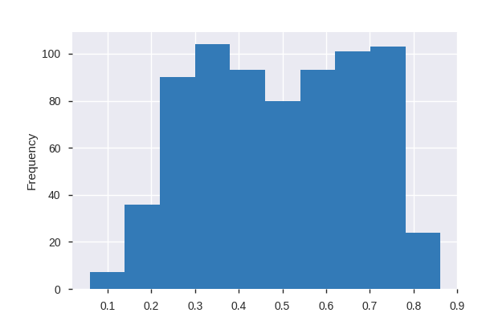

**Common Values**

| Value | Count | Frequency (%) |  |
| --- | --- | --- | --- |
| 0.265833 | 5 | 0.7% |  |
| 0.635 | 5 | 0.7% |  |
| 0.4375 | 4 | 0.5% |  |
| 0.564167 | 4 | 0.5% |  |
| 0.649167 | 4 | 0.5% |  |
| 0.484167 | 4 | 0.5% |  |
| 0.68 | 4 | 0.5% |  |
| 0.696667 | 4 | 0.5% |  |
| 0.710833 | 4 | 0.5% |  |
| 0.514167 | 3 | 0.4% |  |
| Other values (489) | 690 | 94.4% |  |

**Extreme Values**

Minimum 5 values

| Value | Count | Frequency (%) |  |
| --- | --- | --- | --- |
| 0.0591304 | 1 | 0.1% |  |
| 0.0965217 | 1 | 0.1% |  |
| 0.0973913 | 1 | 0.1% |  |
| 0.1075 | 1 | 0.1% |  |
| 0.1275 | 1 | 0.1% |  |

Maximum 5 values

| Value | Count | Frequency (%) |  |
| --- | --- | --- | --- |
| 0.834167 | 1 | 0.1% |  |
| 0.838333 | 1 | 0.1% |  |
| 0.848333 | 1 | 0.1% |  |
| 0.849167 | 1 | 0.1% |  |
| 0.861667 | 1 | 0.1% |  |

weathersit  
Numeric

| Distinct count | 3 |
| --- | --- |
| Unique (%) | 0.4% |
| Missing (%) | 0.0% |
| Missing (n) | 0 |
| Infinite (%) | 0.0% |
| Infinite (n) | 0 |

| Mean | 1.3953 |
| --- | --- |
| Minimum | 1 |
| Maximum | 3 |
| Zeros (%) | 0.0% |

Toggle details

**Statistics**

Quantile statistics

| Minimum | 1 |
| --- | --- |
| 5-th percentile | 1 |
| Q1 | 1 |
| Median | 1 |
| Q3 | 2 |
| 95-th percentile | 2 |
| Maximum | 3 |
| Range | 2 |
| Interquartile range | 1 |

Descriptive statistics

| Standard deviation | 0.54489 |
| --- | --- |
| Coef of variation | 0.39051 |
| Kurtosis | -0.13647 |
| Mean | 1.3953 |
| MAD | 0.50081 |
| Skewness | 0.95739 |
| Sum | 1020 |
| Variance | 0.29691 |
| Memory size | 11.4 KiB |

**Histogram**

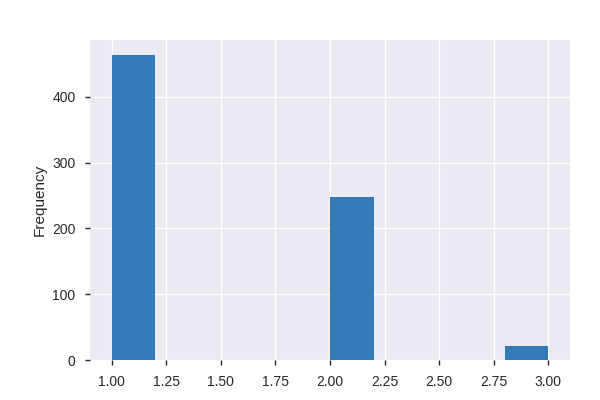

**Common Values**

| Value | Count | Frequency (%) |  |
| --- | --- | --- | --- |
| 1 | 463 | 63.3% |  |
| 2 | 247 | 33.8% |  |
| 3 | 21 | 2.9% |  |

**Extreme Values**

Minimum 5 values

| Value | Count | Frequency (%) |  |
| --- | --- | --- | --- |
| 1 | 463 | 63.3% |  |
| 2 | 247 | 33.8% |  |
| 3 | 21 | 2.9% |  |

Maximum 5 values

| Value | Count | Frequency (%) |  |
| --- | --- | --- | --- |
| 1 | 463 | 63.3% |  |
| 2 | 247 | 33.8% |  |
| 3 | 21 | 2.9% |  |

weekday  
Numeric

| Distinct count | 7 |
| --- | --- |
| Unique (%) | 1.0% |
| Missing (%) | 0.0% |
| Missing (n) | 0 |
| Infinite (%) | 0.0% |
| Infinite (n) | 0 |

| Mean | 2.9973 |
| --- | --- |
| Minimum | 0 |
| Maximum | 6 |
| Zeros (%) | 14.4% |

Toggle details

**Statistics**

Quantile statistics

| Minimum | 0 |
| --- | --- |
| 5-th percentile | 0 |
| Q1 | 1 |
| Median | 3 |
| Q3 | 5 |
| 95-th percentile | 6 |
| Maximum | 6 |
| Range | 6 |
| Interquartile range | 4 |

Descriptive statistics

| Standard deviation | 2.0048 |
| --- | --- |
| Coef of variation | 0.66887 |
| Kurtosis | -1.2543 |
| Mean | 2.9973 |
| MAD | 1.7186 |
| Skewness | 0.0027416 |
| Sum | 2191 |
| Variance | 4.0192 |
| Memory size | 11.4 KiB |

**Histogram**

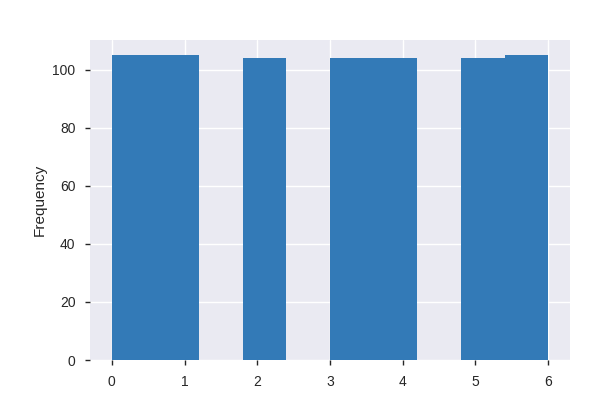

**Common Values**

| Value | Count | Frequency (%) |  |
| --- | --- | --- | --- |
| 6 | 105 | 14.4% |  |
| 1 | 105 | 14.4% |  |
| 0 | 105 | 14.4% |  |
| 5 | 104 | 14.2% |  |
| 4 | 104 | 14.2% |  |
| 3 | 104 | 14.2% |  |
| 2 | 104 | 14.2% |  |

**Extreme Values**

Minimum 5 values

| Value | Count | Frequency (%) |  |
| --- | --- | --- | --- |
| 0 | 105 | 14.4% |  |
| 1 | 105 | 14.4% |  |
| 2 | 104 | 14.2% |  |
| 3 | 104 | 14.2% |  |
| 4 | 104 | 14.2% |  |

Maximum 5 values

| Value | Count | Frequency (%) |  |
| --- | --- | --- | --- |
| 2 | 104 | 14.2% |  |
| 3 | 104 | 14.2% |  |
| 4 | 104 | 14.2% |  |
| 5 | 104 | 14.2% |  |
| 6 | 105 | 14.4% |  |

windspeed  
Numeric

| Distinct count | 650 |
| --- | --- |
| Unique (%) | 88.9% |
| Missing (%) | 0.0% |
| Missing (n) | 0 |
| Infinite (%) | 0.0% |
| Infinite (n) | 0 |

| Mean | 0.19049 |
| --- | --- |
| Minimum | 0.022392 |
| Maximum | 0.50746 |
| Zeros (%) | 0.0% |

Toggle details

**Statistics**

Quantile statistics

| Minimum | 0.022392 |
| --- | --- |
| 5-th percentile | 0.079617 |
| Q1 | 0.13495 |
| Median | 0.18097 |
| Q3 | 0.23321 |
| 95-th percentile | 0.34328 |
| Maximum | 0.50746 |
| Range | 0.48507 |
| Interquartile range | 0.098265 |

Descriptive statistics

| Standard deviation | 0.077498 |
| --- | --- |
| Coef of variation | 0.40684 |
| Kurtosis | 0.41092 |
| Mean | 0.19049 |
| MAD | 0.061223 |
| Skewness | 0.67735 |
| Sum | 139.25 |
| Variance | 0.0060059 |
| Memory size | 11.4 KiB |

**Histogram**

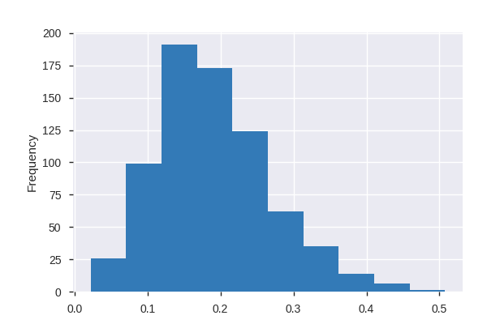

**Common Values**

| Value | Count | Frequency (%) |  |
| --- | --- | --- | --- |
| 0.228858 | 3 | 0.4% |  |
| 0.11879200000000001 | 3 | 0.4% |  |
| 0.134954 | 3 | 0.4% |  |
| 0.149883 | 3 | 0.4% |  |
| 0.166667 | 3 | 0.4% |  |
| 0.1107 | 3 | 0.4% |  |
| 0.136817 | 3 | 0.4% |  |
| 0.16791199999999998 | 3 | 0.4% |  |
| 0.10635 | 3 | 0.4% |  |
| 0.116908 | 2 | 0.3% |  |
| Other values (640) | 702 | 96.0% |  |

**Extreme Values**

Minimum 5 values

| Value | Count | Frequency (%) |  |
| --- | --- | --- | --- |
| 0.0223917 | 1 | 0.1% |  |
| 0.0423042 | 1 | 0.1% |  |
| 0.0454042 | 1 | 0.1% |  |
| 0.045408300000000006 | 1 | 0.1% |  |
| 0.04665 | 1 | 0.1% |  |

Maximum 5 values

| Value | Count | Frequency (%) |  |
| --- | --- | --- | --- |
| 0.417908 | 1 | 0.1% |  |
| 0.421642 | 1 | 0.1% |  |
| 0.422275 | 1 | 0.1% |  |
| 0.441563 | 1 | 0.1% |  |
| 0.507463 | 1 | 0.1% |  |

workingday  
Boolean

| Distinct count | 2 |
| --- | --- |
| Unique (%) | 0.3% |
| Missing (%) | 0.0% |
| Missing (n) | 0 |

| Mean | 0.68399 |
| --- | --- |

| 1 | 500 |
| --- | --- |
| 0 | 231 |

Toggle details

| Value | Count | Frequency (%) |  |
| --- | --- | --- | --- |
| 1 | 500 | 68.4% |  |
| 0 | 231 | 31.6% |  |

yr  
Boolean

| Distinct count | 2 |
| --- | --- |
| Unique (%) | 0.3% |
| Missing (%) | 0.0% |
| Missing (n) | 0 |

| Mean | 0.50068 |
| --- | --- |

| 1 | 366 |
| --- | --- |
| 0 | 365 |

Toggle details

| Value | Count | Frequency (%) |  |
| --- | --- | --- | --- |
| 1 | 366 | 50.1% |  |
| 0 | 365 | 49.9% |  |

Correlations

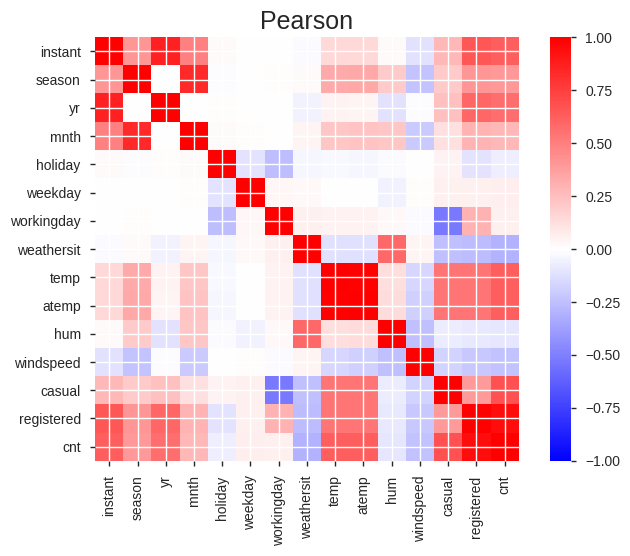

[1 more figures not shown]

Sample

|  | instant | dteday | season | yr | mnth | holiday | weekday | workingday | weathersit | temp | atemp | hum | windspeed | casual | registered | cnt |
| --- | --- | --- | --- | --- | --- | --- | --- | --- | --- | --- | --- | --- | --- | --- | --- | --- |
| 0 | 1 | 2011-01-01 | 1 | 0 | 1 | 0 | 6 | 0 | 2 | 0.344167 | 0.363625 | 0.805833 | 0.160446 | 331 | 654 | 985 |
| 1 | 2 | 2011-01-02 | 1 | 0 | 1 | 0 | 0 | 0 | 2 | 0.363478 | 0.353739 | 0.696087 | 0.248539 | 131 | 670 | 801 |
| 2 | 3 | 2011-01-03 | 1 | 0 | 1 | 0 | 1 | 1 | 1 | 0.196364 | 0.189405 | 0.437273 | 0.248309 | 120 | 1229 | 1349 |
| 3 | 4 | 2011-01-04 | 1 | 0 | 1 | 0 | 2 | 1 | 1 | 0.200000 | 0.212122 | 0.590435 | 0.160296 | 108 | 1454 | 1562 |
| 4 | 5 | 2011-01-05 | 1 | 0 | 1 | 0 | 3 | 1 | 1 | 0.226957 | 0.229270 | 0.436957 | 0.186900 | 82 | 1518 | 1600 |

```python
import pandas_profiling
pandas_profiling.ProfileReport(df)
```

## Time series plot

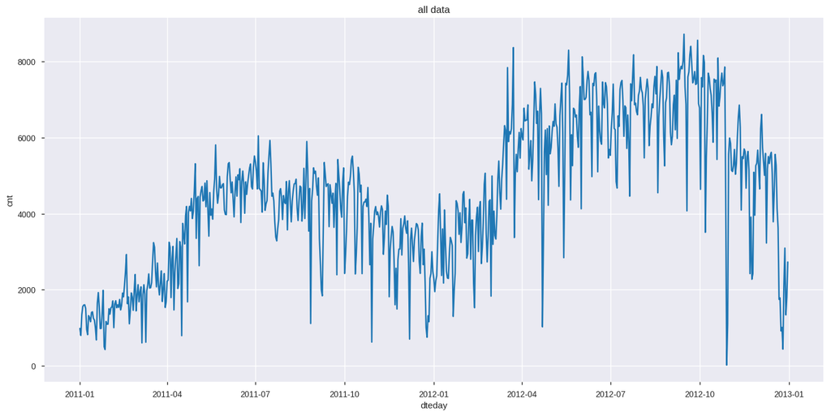

```python
f, ax = plt.subplots(figsize=(17,8)) # Create a figure and one subplot
g=sns.lineplot(x="dteday", y="cnt", data=df) # Plot the response over time
plt.title("all data")
plt.show(g)
```

# Stationary

- 1st step in time series modeling: remove the effects of the trend or season
- Statistical modeling methods assume or require the time series to be stationary to be effective
- A stationary series is one where the mean of the series is no longer a function of time

## Stationary Time Series and Forecasting

Should you make your time series stationary?

Generally, yes.

If you have clear trend and seasonality in your time series, then model these components, remove them from observations, then train models on the residuals.

Statistical time series methods and even modern machine learning methods will benefit from the clearer signal in the data.

But…

We turn to machine learning methods when the classical methods fail. When we want more or better results. We cannot know how to best model unknown nonlinear relationships in time series data and some methods may result in better performance when working with non-stationary observations or some mixture of stationary and non-stationary views of the problem.

The suggestion here is to treat properties of a time series being stationary or not as another source of information that can be used in feature engineering and feature selection on your time series problem when using machine learning methods.

## How do we achieve stationarity?

There are two methods that can be applied to achieve stationarity, difference the data or linear regression.

https://www.kdnuggets.com/2018/03/time-series-dummies-3-step-process.html  
https://machinelearningmastery.com/time-series-data-stationary-python/

# Is our data stationary or non-stationary?

```python
# to check, run the augmented Dickey-Fuller test:
from statsmodels.tsa.stattools import adfuller
result = adfuller(df["cnt"].values)
print('ADF Statistic: %f' % result[0])
print('p-value: %f' % result[1])
print('Critical Values:')
for key, value in result[4].items():
    print('\t%s: %.3f' % (key, value))
```

```
ADF Statistic: -1.877448
p-value: 0.342743
Critical Values:
	1%: -3.440
	5%: -2.866
	10%: -2.569
```

**=> we fail to reject H0**

**=> our data is non-stationary and should (most likely) be transformed!**